# Feed Forward Regressor NN to Predict Medicare Payout

For my final project in my AI course, I built a feed forward regressor neural network to predict Medicare payouts to physicians and practices based on the Center for Medicare and Medicaid (CMS) dataset that I also analyzed in two previous notebooks.

My objective was to use the Keras package to iteratively and empirically develop a supervised, feed forward regressor neural network that learned to predict total annual Medicare payouts for medical practitioners and practices in the US based on numerous characteristics describing their businesses and patients. I accomplished this by building a model using Dense layers and experimenting with different kernel initializers, layer width, layer depths, optimizers and learning rate.

In the preliminary modeling, I achieved a test MSE of 0.074 with a non-pruned random forest regressor model. I set this MSE as my target MSE to beat with my neural network.

```python
import warnings
warnings.filterwarnings('ignore')

import datetime
import pandas as pd
import numpy as np
import matplotlib.pyplot as plt

from sklearn.preprocessing import MinMaxScaler
from sklearn.model_selection import KFold

from keras.layers import Dense
from keras.models import Sequential
from keras.optimizers import Adamax

import warnings
warnings.filterwarnings('ignore')
```

### Summary of Final Model

The model has three hidden Dense layers with widths 300, 500 and 250. All hidden layers use ‘relu’ as their activation function. The output layer has one node and the activation function is ‘linear’ to perform a regression. The optimizer is ‘Adamax’ and the loss function is ‘mse’. The model runs on 75 epochs and a batch size of 400. It is also cross validated using 3-fold cross validation. I collected the MSE values at each epoch and averaged them across all 3 folds to assess the performance of my model. I call evaluate() to assess the performance of the model and summary() to describe the parameters.

```python
#Load the dataset
df = pd.read_csv('medicare.csv', header=0)

#Pop off the name of the dependent variable
cols = list(df.columns.values)
Y_name = cols.pop(cols.index('Total_Medicare_Payout_log'))

# Define the X and Y columns, independent and dependent variables
Y = df[Y_name]
X = df.drop([Y_name], axis=1)

# normalize the data in each numeric variable, while excluding the binary encoded
scaler = MinMaxScaler()
X.iloc[:,24:55] = scaler.fit_transform(X.iloc[:,24:55])

# Turn the data into numpy arrays for use in neural networks
X = X.to_numpy()
Y = Y.to_numpy()
```

### Model Depth

I began model development by establishing a baseline model and experimenting with model depth. The baseline model had 2 shallow dense layers with 50 and 100 layers, respectively. The model was only trained on 20 epochs per K-fold CV and batch size of 500. The model trained in 1 minute and 43 seconds and produced a test MSE was 0.1518. After evaluating the plot of training and validation loss, it seemed that the model could benefit from increased depth and training time.

My next model increased layer depth five-fold, from 50 and 100 to 250 and 500, respectively. Additionally, epochs were increased from 20 to 35. This drastically increased the parameters (while staying under the 300k instance threshold) and reduced test MSE to 0.1032. There was still room to add more parameters and train the model even longer, however.

In my third model I increased layer depth from 250 and 500 to 350 and 600, respectively, increased epochs to 100 and reduced batch size from 500 to 100. This drastically increased training time from ~3 minutes to 41 minutes. It also increased the number of parameters from ~140K to ~230K. The test MSE was 0.0756 which was close to achieving my original goal. The training, validation loss plot indicated that there was perhaps too much traing time taking place as validation loss began creeping above training loss, indicating over-fitting.

I settled on moving forward with a model that trains on 50 epochs and batch size of 400.

```python
k_splits = 3 # 3-Fold CV
num_epochs = 75 # Training length
b_size = 400 # Frequency of batch size update

#Number of nodes per layer
layer1_node = 300
layer2_node = 500
layer3_node = 250
```

### Model Width and Optimizers

In the next model, I added another dense layer with 250 nodes and cut the number of nodes in the first two layers. The three layers had 300, 500 and 250 layers, respectively. This brought total parameters to ~292K which is still under my target threshold.

Additionally, I experimented with different optimizers. Up until now I had been using the Adam optimizer which has been empirically tested in the AI community and continually demonstrates good and fast results. The Adam optimizer combines the advantages of both the RMSprop and AdaGrad optimizers.

I used the GridSearchCV() function from SK-Learn to test my current model with 5 optimizers: SGD, RMSprop, Adam, Adamax, and Nadam. The GridSearchCV() results yielded a lowest test MSE for RMSprop, however, when I used RMSprop in my original script I yielded a very poor test MSE. This led me to try all 5 optimizers in my original script. Adamax scored the lowest with a test MSE of 0.0793, as compated to a test MSE of 0.08147 with Adam.

### Incorporating Learning Rate

Learning rate controls how quickly the model adapts to a problem. A small learning rate will require more training epochs because smaller changes are made to the weights each update. A large learning rate will result in rapid changes but may cause the model to quickly converge on a suboptimal solution.

I tested numerous learning rates, starting at 0.01 and working down as small as 0.001. I compared validation MSE to evaluate model performance. Additionally, because I used small learning rates, I increased model training time from 50 epochs to 75 epochs and decreased the batch size to 400.

### The Final Model

```
Model Evaluation: [0.07379970081524334, 0.07379970081524334]
Model Evaluation: [0.07887140383172664, 0.07887140383172664]
Model Evaluation: [0.0747654646466343, 0.0747654646466343]
Time required for training: 0:08:18.411362
```

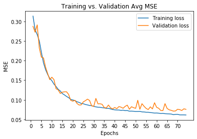

```
After  75  epochs the avg validation MSE is  0.07581218153993259  with K-folds equal to  3
_________________________________________________________________
Layer (type)                 Output Shape              Param #
=================================================================
dense_21 (Dense)             (None, 300)               16800
_________________________________________________________________
dense_22 (Dense)             (None, 500)               150500
_________________________________________________________________
dense_23 (Dense)             (None, 250)               125250
_________________________________________________________________
dense_24 (Dense)             (None, 1)                 251
=================================================================
Total params: 292,801
Trainable params: 292,801
Non-trainable params: 0
_________________________________________________________________
```

```python
warnings.filterwarnings('ignore')

start_time = datetime.datetime.now()
#create model
def create_model():
    model=Sequential()
    model.add(Dense(layer1_node, input_dim=X.shape[1], kernel_initializer = 'random_uniform',
                    bias_initializer = 'zero', activation='relu')) #First hidden layer
    model.add(Dense(layer2_node, activation='relu')) # Second hidden layer
    model.add(Dense(layer3_node, activation='relu')) # Third hidden layer
    model.add(Dense(1, activation='linear')) #Output layer. Must be linear activation for a regressor
    opt = Adamax(lr=0.0035) # Define optimizer with unique learning rate
    model.compile(optimizer=opt, loss='mean_squared_error', metrics = ['mse']) # Specify loss function
    return model

"""""""""""""""""""""""""""""""""""""""""""""""""""""""""""""""""""""""""""
Train Model Section
"""""""""""""""""""""""""""""""""""""""""""""""""""""""""""""""""""""""""""
""" Specify training methodology, in this case, K-fold CV"""
#K-Fold cross validation
mses_train = []
mses_val_loss = []

# Set random seed for reproducibility
np.random.seed(360)

# Use KFold function from sk-learn
for train_index, test_index in KFold(n_splits = k_splits, shuffle=False, random_state=None).split(X):
    x_train, x_test = X[train_index], X[test_index] # Split Xs
    y_train, y_test = Y[train_index], Y[test_index] # Split Ys
    model = create_model() # initialize model
    history = model.fit(x_train, y_train, batch_size = b_size, epochs= num_epochs, verbose=0, validation_data=(x_test, y_test)) #store memory of model performance
    print('Model Evaluation:', model.evaluate(x_test,y_test)) # Evaluate model

    train_mse = history.history['mean_squared_error'] # call train MSE
    val_loss_mse = history.history['val_mean_squared_error'] # call validation MSE


    mses_train.append(train_mse)
    mses_val_loss.append(val_loss_mse)


avg_train_mse = [np.mean([x[i] for x in mses_train]) for i in range(num_epochs)] #Average training MSEs across epochs
avg_val_mse = [np.mean([x[i] for x in mses_val_loss]) for i in range(num_epochs)] # Average validation MSEs across epochs


avg_train_mse = avg_train_mse[1:] # Exclude first row with no value
avg_val_mse = avg_val_mse[1:] # Exclude first row with no value


"""""""""""""""""""""""""""""""""""""""""""""""""""""""""""""""""""""""""""
Show output Section
"""""""""""""""""""""""""""""""""""""""""""""""""""""""""""""""""""""""""""
""" Plot the output of the model to evaluate performance """
stop_time = datetime.datetime.now()
print("Time required for training:", stop_time - start_time)

plt.plot(range (1, len(avg_train_mse) + 1), avg_train_mse, label='Training loss')
plt.plot(range (1, len(avg_val_mse) + 1), avg_val_mse, label='Validation loss')
plt.xticks(np.arange(0, 75, step=5))
plt.title("Training vs. Validation Avg MSE")
plt.ylabel('MSE')
plt.xlabel('Epochs')
#plt.xticks([range(1, len(num_epochs), step=5)])
plt.legend()
plt.show()

# Print final validation MSE at the end of training across all 3 Folds
print('After ', num_epochs, ' epochs the avg validation MSE is ',avg_val_mse[num_epochs-2], ' with K-folds equal to ', k_splits )
model.summary() # Call model structure
```

### Conclusion

The model is complex with 292,801 parameters. Depending on the objective of deploying this model it might make more sense to limit the number of parameters. A high number of parameters tends to detract from generalizability. On the other hand, a validation MSE of 0.07 is pretty good and still suggests generalizability. Given the large dimensionality of the dataset, perhaps the model needed to be complex to extract meaning from all the features.